# Day 3: Microbial Taxonomic and Functional Ecology

UCD Bioinformatics Course 2026

2026-06-30

## Overview

In this activity we will analyze metagenomic data from urban and natural soil environments to ask: **does urbanization alter the taxonomic and functional diversity of soil microbial communities?**

We have three data files:

| File | Contents |
| --- | --- |
| `metadata.csv` | Sample information including site, urban/natural classification, and total sequencing reads |
| `taxonomy_counts_table.csv` | Raw read counts assigned to each bacterial taxon per sample |
| `ko_table.txt` | Raw read counts assigned to each KEGG Ortholog (KO) functional gene per sample |

We will work through four main steps: (1) data loading and normalization, (2) alpha diversity, (3) correlations between taxonomic and functional diversity, and (4) beta diversity.

## 1. Setup

### Load Libraries

```r
library(tidyverse)   # data wrangling and plotting
library(vegan)       # community ecology analyses (diversity, ordination, PERMANOVA)
library(car)         # Type II ANOVA for mixed models
library(lme4)        # linear mixed effects models
library(ggpubr)      # correlation statistics on ggplots
```

## 2. Load and Inspect Data

```r
# ---- Metadata
md <- read_csv("../../data/metadata.csv")
glimpse(md)
```

```
## Rows: 24
## Columns: 10
## $ sample             <chr> "11B.T1.3", "11B.T1.6", "11B.T1.9", "8.T1.3", "8.T1…
## $ total_reads        <dbl> 34582660, 40572243, 29565867, 30636381, 25383741, 4…
## $ site               <chr> "11", "11", "11", "8", "8", "8", "Ex45", "Ex45", "E…
## $ urban              <chr> "natural", "natural", "natural", "natural", "natura…
## $ pH                 <dbl> 6.55, 6.18, 6.47, 6.85, 6.47, 6.06, 7.15, 7.05, 6.6…
## $ moisture_pct       <dbl> 23.7, 18.5, 19.0, 25.5, 20.9, 24.2, 27.6, 30.7, 25.…
## $ OC_pct             <dbl> 2.51, 1.83, 2.37, 1.68, 1.62, 2.79, 2.92, 2.56, 3.2…
## $ totalN_mg_kg       <dbl> 829, 1540, 1184, 1085, 1083, 1019, 1640, 1788, 1230…
## $ totalP_mg_kg       <dbl> 208, 209, 182, 202, 222, 198, 372, 228, 231, 492, 3…
## $ bulk_density_g_cm3 <dbl> 1.37, 1.24, 1.27, 1.21, 1.29, 1.11, 1.25, 1.07, 1.2…
```

```r
summary(md)
```

```
##     sample           total_reads           site              urban
##  Length:24          Min.   :25383741   Length:24          Length:24
##  Class :character   1st Qu.:30277950   Class :character   Class :character
##  Mode  :character   Median :33825886   Mode  :character   Mode  :character
##                     Mean   :35428164
##                     3rd Qu.:37106570
##                     Max.   :61105895
##        pH         moisture_pct       OC_pct       totalN_mg_kg   totalP_mg_kg
##  Min.   :6.060   Min.   : 9.50   Min.   :1.180   Min.   : 494   Min.   :138.0
##  1st Qu.:6.630   1st Qu.:15.25   1st Qu.:1.597   1st Qu.: 811   1st Qu.:201.0
##  Median :7.025   Median :19.75   Median :1.995   Median :1084   Median :225.0
##  Mean   :7.097   Mean   :20.34   Mean   :2.133   Mean   :1087   Mean   :259.6
##  3rd Qu.:7.475   3rd Qu.:25.35   3rd Qu.:2.580   3rd Qu.:1278   3rd Qu.:326.0
##  Max.   :8.140   Max.   :31.60   Max.   :3.740   Max.   :1977   Max.   :492.0
##  bulk_density_g_cm3
##  Min.   :1.010
##  1st Qu.:1.210
##  Median :1.280
##  Mean   :1.307
##  3rd Qu.:1.387
##  Max.   :1.680
```

```r
# Check for missing values per column
md %>% summarise(across(everything(), ~ sum(is.na(.))))
```

```
## # A tibble: 1 × 10
##   sample total_reads  site urban    pH moisture_pct OC_pct totalN_mg_kg
##    <int>       <int> <int> <int> <int>        <int>  <int>        <int>
## 1      0           0     0     0     0            0      0            0
## # ℹ 2 more variables: totalP_mg_kg <int>, bulk_density_g_cm3 <int>
```

```r
# ---- Taxonomic count table
taxonomy_counts <- read_csv("../../data/taxonomy_counts_table.csv")
glimpse(taxonomy_counts)
```

```
## Rows: 9,905
## Columns: 25
## $ taxon      <chr> "Microbacterium sp. No. 7", "Microbacterium sp. JZ31", "Mic…
## $ `11B.T1.3` <dbl> 6433, 4868, 4404, 4251, 4212, 4530, 3876, 2751, 2930, 4283,…
## $ `11B.T1.6` <dbl> 7660, 4698, 4346, 4333, 4378, 4650, 4240, 2893, 3206, 4336,…
## $ `11B.T1.9` <dbl> 5562, 2985, 2700, 2676, 2591, 2790, 2500, 1745, 1973, 3424,…
## $ `8.T1.3`   <dbl> 5315, 3429, 3519, 3382, 3106, 3370, 3296, 2234, 2344, 3143,…
## $ `8.T1.6`   <dbl> 3817, 2357, 2182, 2131, 2253, 2176, 2045, 1293, 1620, 2091,…
## $ `8.T1.9`   <dbl> 6719, 3920, 3823, 3690, 3705, 3766, 3734, 2369, 2751, 4033,…
## $ Ex45.T1.3  <dbl> 4316, 2823, 2714, 2556, 2474, 2713, 2946, 1722, 1700, 2515,…
## $ Ex45.T1.6  <dbl> 5480, 2859, 2820, 2738, 2575, 2751, 2588, 1805, 1902, 3358,…
## $ Ex45.T1.9  <dbl> 4845, 2546, 2618, 2373, 2647, 2429, 2166, 1569, 1693, 2884,…
## $ HP.T1.3    <dbl> 5841, 3547, 3498, 3237, 3350, 3283, 3238, 2195, 2183, 3308,…
## $ HP.T1.6    <dbl> 6178, 3949, 4028, 3754, 3629, 3834, 3575, 2623, 2682, 3570,…
## $ HP.T1.9    <dbl> 7491, 4687, 4717, 4098, 3872, 4284, 3987, 2819, 2869, 4525,…
## $ RC.T1.3    <dbl> 4258, 2548, 2505, 2433, 2294, 2865, 2546, 1830, 1981, 2624,…
## $ RC.T1.6    <dbl> 3357, 2225, 1964, 2071, 1941, 2271, 2005, 1426, 1575, 1939,…
## $ RC.T1.9    <dbl> 3370, 1977, 1800, 1868, 2030, 2104, 1993, 1353, 1424, 1861,…
## $ RP.T1.3    <dbl> 10113, 6061, 6175, 5327, 5419, 5990, 5676, 4052, 3975, 5981…
## $ RP.T1.6    <dbl> 11206, 6954, 7184, 5646, 6164, 6682, 6081, 4498, 4569, 7780…
## $ RP.T1.9    <dbl> 6676, 4246, 4299, 3541, 3852, 4177, 3798, 2688, 2642, 4295,…
## $ SC.T1.3    <dbl> 6706, 3935, 3555, 3503, 3366, 3732, 3664, 2312, 2535, 3851,…
## $ SC.T1.6    <dbl> 5093, 2842, 2709, 2816, 2595, 2822, 2739, 1883, 1953, 2761,…
## $ SC.T1.9    <dbl> 4290, 2546, 2333, 2545, 2282, 2552, 2258, 1619, 1810, 2300,…
## $ UAB.T1.3   <dbl> 4907, 2869, 2759, 2828, 2650, 2891, 2706, 1817, 1768, 2671,…
## $ UAB.T1.6   <dbl> 11651, 7739, 8174, 7532, 7386, 8166, 6928, 4837, 5367, 7456…
## $ UAB.T1.9   <dbl> 6602, 4376, 4474, 4269, 4193, 4366, 4063, 2814, 3064, 4125,…
```

```r
# Check for NAs — these represent taxa absent in a sample (true zeros), so we replace them
taxonomy_counts %>% summarise(across(everything(), ~ sum(is.na(.))))
```

```
## # A tibble: 1 × 25
##   taxon `11B.T1.3` `11B.T1.6` `11B.T1.9` `8.T1.3` `8.T1.6` `8.T1.9` Ex45.T1.3
##   <int>      <int>      <int>      <int>    <int>    <int>    <int>     <int>
## 1     0       2490       2417       2687     2664     2753     2360      2893
## # ℹ 17 more variables: Ex45.T1.6 <int>, Ex45.T1.9 <int>, HP.T1.3 <int>,
## #   HP.T1.6 <int>, HP.T1.9 <int>, RC.T1.3 <int>, RC.T1.6 <int>, RC.T1.9 <int>,
## #   RP.T1.3 <int>, RP.T1.6 <int>, RP.T1.9 <int>, SC.T1.3 <int>, SC.T1.6 <int>,
## #   SC.T1.9 <int>, UAB.T1.3 <int>, UAB.T1.6 <int>, UAB.T1.9 <int>
```

```r
taxonomy_counts <- taxonomy_counts %>%
  mutate(across(where(is.numeric), ~ replace_na(., 0)))
```

```r
# ---- Gene (KO) count table
ko_counts <- read_table("../../data/ko_table.txt")
glimpse(ko_counts)
```

```
## Rows: 6,211
## Columns: 25
## $ KO         <chr> "K00003", "K00004", "K00005", "K00008", "K00009", "K00010",…
## $ `11B.T1.3` <dbl> 3369, 141, 18, 512, 118, 1760, 3807, 1335, 1431, 465, 144, …
## $ `11B.T1.6` <dbl> 3208, 163, 31, 421, 68, 2023, 3629, 879, 1269, 277, 38, 108…
## $ `11B.T1.9` <dbl> 2153, 136, 12, 192, 17, 823, 2159, 354, 756, 133, 47, 52, 4…
## $ `8.T1.3`   <dbl> 2509, 134, 18, 360, 76, 1945, 3065, 729, 997, 316, 29, 62, …
## $ `8.T1.6`   <dbl> 1665, 35, 10, 173, 14, 400, 1819, 390, 512, 181, 26, 26, 19…
## $ `8.T1.9`   <dbl> 2604, 92, 26, 172, 32, 804, 3540, 573, 1085, 363, 129, 285,…
## $ Ex45.T1.3  <dbl> 2203, 277, 39, 303, 151, 1863, 2413, 877, 1088, 370, 41, 66…
## $ Ex45.T1.6  <dbl> 2127, 205, 38, 232, 94, 1345, 2508, 728, 970, 442, 73, 124,…
## $ Ex45.T1.9  <dbl> 1396, 70, 46, 124, 127, 904, 1999, 763, 797, 327, 68, 73, 5…
## $ HP.T1.3    <dbl> 3928, 126, 179, 564, 435, 2217, 6330, 2365, 2622, 721, 57, …
## $ HP.T1.6    <dbl> 4916, 108, 104, 145, 281, 1467, 6023, 2627, 2576, 970, 403,…
## $ HP.T1.9    <dbl> 6252, 304, 120, 262, 447, 2126, 7391, 3258, 3395, 636, 169,…
## $ RC.T1.3    <dbl> 2452, 1, 0, 85, 73, 425, 2728, 677, 1054, 113, 48, 28, 347,…
## $ RC.T1.6    <dbl> 2070, 1, 2, 58, 27, 424, 1997, 376, 854, 449, 41, 50, 317, …
## $ RC.T1.9    <dbl> 1761, 5, 2, 23, 6, 332, 1764, 383, 697, 236, 16, 84, 280, 1…
## $ RP.T1.3    <dbl> 8301, 1157, 1267, 1039, 1616, 8304, 17072, 7738, 8622, 3704…
## $ RP.T1.6    <dbl> 7921, 447, 378, 811, 534, 4394, 10871, 4432, 5059, 914, 136…
## $ RP.T1.9    <dbl> 4924, 307, 257, 410, 620, 2847, 6952, 3123, 3421, 927, 747,…
## $ SC.T1.3    <dbl> 3572, 503, 54, 600, 107, 1887, 4798, 1827, 2233, 608, 82, 7…
## $ SC.T1.6    <dbl> 1915, 179, 64, 177, 316, 1232, 2974, 795, 1185, 585, 235, 2…
## $ SC.T1.9    <dbl> 1652, 169, 65, 170, 413, 1454, 2760, 939, 1319, 903, 122, 8…
## $ UAB.T1.3   <dbl> 2215, 131, 38, 463, 129, 1896, 2854, 740, 970, 272, 84, 58,…
## $ UAB.T1.6   <dbl> 6878, 404, 56, 1261, 431, 6228, 7508, 1986, 3430, 751, 78, …
## $ UAB.T1.9   <dbl> 3390, 157, 15, 789, 204, 3592, 3877, 1145, 1635, 365, 48, 9…
```

```r
ko_counts %>% summarise(across(everything(), ~ sum(is.na(.))))
```

```
## # A tibble: 1 × 25
##      KO `11B.T1.3` `11B.T1.6` `11B.T1.9` `8.T1.3` `8.T1.6` `8.T1.9` Ex45.T1.3
##   <int>      <int>      <int>      <int>    <int>    <int>    <int>     <int>
## 1     0          0          0          0        0        0        0         0
## # ℹ 17 more variables: Ex45.T1.6 <int>, Ex45.T1.9 <int>, HP.T1.3 <int>,
## #   HP.T1.6 <int>, HP.T1.9 <int>, RC.T1.3 <int>, RC.T1.6 <int>, RC.T1.9 <int>,
## #   RP.T1.3 <int>, RP.T1.6 <int>, RP.T1.9 <int>, SC.T1.3 <int>, SC.T1.6 <int>,
## #   SC.T1.9 <int>, UAB.T1.3 <int>, UAB.T1.6 <int>, UAB.T1.9 <int>
```

## 3. Reorder Data

Before calculating diversity metrics, we must ensure that rows in all three tables correspond to the same samples in the same order. This prevents silent mismatches later.

```r
md <- md %>%
  arrange(sample)

taxonomy_counts <- taxonomy_counts %>%
  column_to_rownames(var = "taxon") %>%
  t() %>%
  as.data.frame() %>%
  rownames_to_column(var = "sample") %>%
  arrange(sample)

ko_counts <- ko_counts %>%
  column_to_rownames(var = "KO") %>%
  t() %>%
  as.data.frame() %>%
  rownames_to_column(var = "sample") %>%
  arrange(sample)

# Verify alignment — both should return TRUE
all(md$sample == taxonomy_counts$sample)
```

```
## [1] TRUE
```

```r
all(md$sample == ko_counts$sample)
```

```
## [1] TRUE
```

## 4. Normalization

### Why normalize?

Raw read counts are influenced by **sequencing depth**: a sample with 10 million reads will always appear to have more of everything than one with 5 million reads, regardless of true biology. To make samples comparable, we normalize counts to **Reads Per Million (RPM)**:

$$\text{RPM} = \frac{\text{raw
count}}{\text{total reads}} \times 10^6$$

This scales each sample’s counts to what we’d expect if every sample had exactly 1 million reads, allowing fair comparisons of relative abundance across samples.

> **Note:** RPM is appropriate for between-sample comparisons of relative abundance. For alpha diversity (next section), we use a different approach — rarefaction — which is better suited for richness-based comparisons.

```r
# Extract total reads from metadata
total_reads_table <- md %>%
  select(sample, total_reads)

# Normalize taxonomy counts to RPM
rpm_taxonomy_counts <- taxonomy_counts %>%
  pivot_longer(-sample, names_to = "taxon", values_to = "count") %>%
  left_join(total_reads_table, by = "sample") %>%
  mutate(RPM = (count / total_reads) * 1e6) %>%
  select(-count, -total_reads) %>%
  pivot_wider(names_from = "taxon", values_from = "RPM")

# Normalize KO counts to RPM
rpm_ko_counts <- ko_counts %>%
  pivot_longer(-sample, names_to = "KO", values_to = "count") %>%
  left_join(total_reads_table, by = "sample") %>%
  mutate(RPM = (count / total_reads) * 1e6) %>%
  select(-count, -total_reads) %>%
  pivot_wider(names_from = "KO", values_from = "RPM")
```

## 5. Alpha Diversity

### What is alpha diversity?

**Alpha diversity** describes the diversity *within* a single sample. The two most common measures are:

- **Richness** — the number of distinct taxa (or functional genes) observed. Simple to interpret, but sensitive to rare species and sequencing depth.
- **Shannon index (H’)** — accounts for both richness *and* evenness (how evenly reads are distributed among taxa):

$$H' = -\sum_{i=1}^{S} p_i
\ln(p_i)$$

where $p_i$ is the relative abundance of taxon $i$ and $S$ is total richness. A community where one taxon dominates has low Shannon diversity even if richness is high.

### Why rarefy before calculating diversity?

Samples sequenced to greater depth will almost always appear more diverse — simply because we’ve sampled more. **Rarefaction** corrects for this by randomly subsampling each sample down to the same number of reads (the rarefaction depth) before calculating diversity. Any sample with fewer reads than this threshold must be excluded.

We first check the distribution of per-sample read totals to choose an appropriate rarefaction depth:

```r
taxonomy_counts_forrich <- taxonomy_counts %>%
  column_to_rownames(var = "sample")

# Examine the distribution of total reads per sample
summary(rowSums(taxonomy_counts_forrich))
```

```
##     Min.  1st Qu.   Median     Mean  3rd Qu.     Max.
##  7734272  8721982 10583015 11650390 12799845 22391577
```

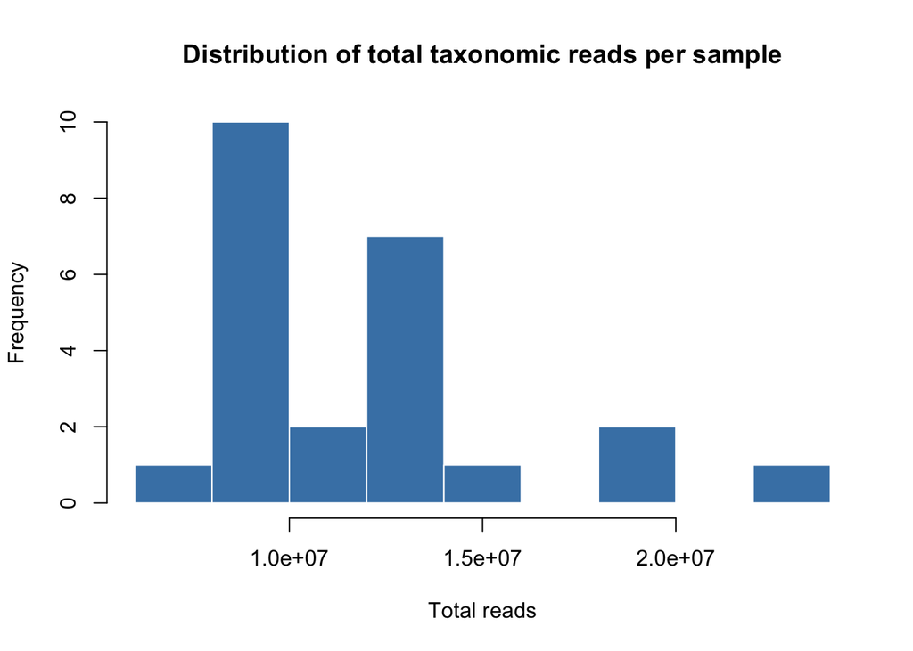

```r
hist(rowSums(taxonomy_counts_forrich),
     main = "Distribution of total taxonomic reads per sample",
     xlab = "Total reads", col = "steelblue", border = "white")
```

We rarefy to **7,734,272 reads** — approximately the minimum sample depth in this dataset. Samples below this threshold are dropped from diversity calculations.

```r
# Calculate taxonomic richness and Shannon diversity on rarefied counts
set.seed(42)  # rarefaction is random subsampling, so set a seed for reproducibility
md$taxonomic_rich    <- specnumber(rrarefy(taxonomy_counts_forrich, sample = 7734272))
md$taxonomic_shannon <- diversity(rrarefy(taxonomy_counts_forrich, sample = 7734272),
                                  index = "shannon")
```

```r
ko_counts_forrich <- ko_counts %>%
  column_to_rownames(var = "sample")

summary(rowSums(ko_counts_forrich))
```

```
##     Min.  1st Qu.   Median     Mean  3rd Qu.     Max.
##  2352294  3767742  4811772  6351043  7755540 21881727
```

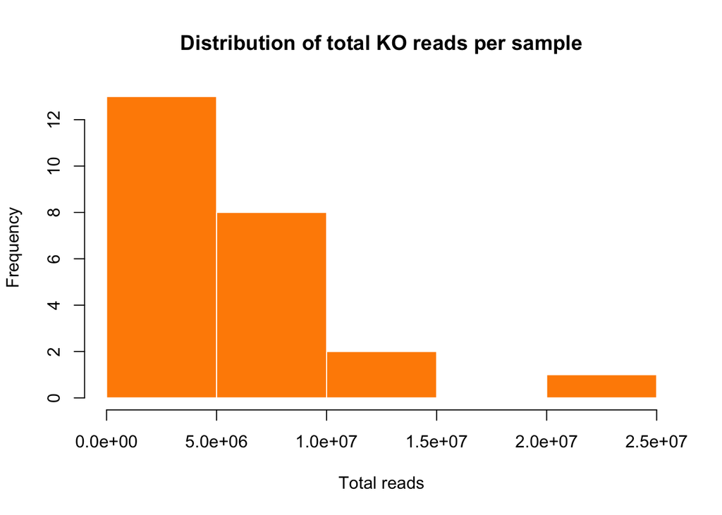

```r
hist(rowSums(ko_counts_forrich),
     main = "Distribution of total KO reads per sample",
     xlab = "Total reads", col = "darkorange", border = "white")
```

```r
set.seed(42)
md$functional_rich    <- specnumber(rrarefy(ko_counts_forrich, sample = 2352294))
md$functional_shannon <- diversity(rrarefy(ko_counts_forrich, sample = 2352294),
                                   index = "shannon")

# Convert grouping variables to factors for plotting and modeling
md$urban <- as.factor(md$urban)
md$site  <- as.factor(md$site)
```

### Alpha Diversity Plots

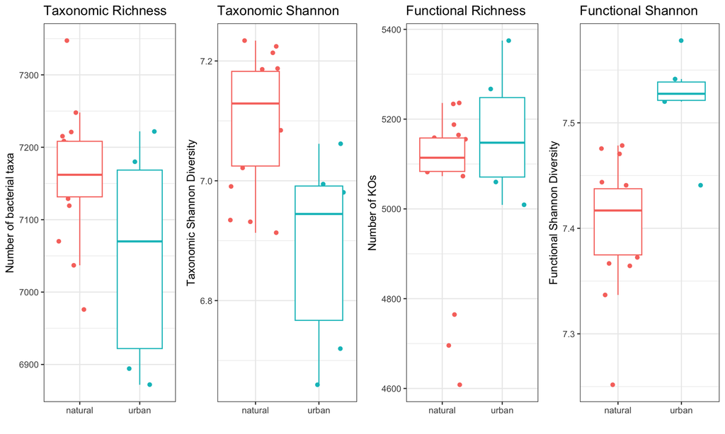

```r
p1 <- ggplot(md, aes(x = urban, y = taxonomic_rich)) +
  geom_jitter(aes(color = urban)) +
  geom_boxplot(aes(color = urban), outliers = FALSE) +
  xlab("") + ylab("Number of bacterial taxa") +
  theme_bw() + theme(legend.position = "none") +
  ggtitle("Taxonomic Richness")

p2 <- ggplot(md, aes(x = urban, y = taxonomic_shannon)) +
  geom_jitter(aes(color = urban)) +
  geom_boxplot(aes(color = urban), outliers = FALSE) +
  xlab("") + ylab("Taxonomic Shannon Diversity") +
  theme_bw() + theme(legend.position = "none") +
  ggtitle("Taxonomic Shannon")

p3 <- ggplot(md, aes(x = urban, y = functional_rich)) +
  geom_jitter(aes(color = urban)) +
  geom_boxplot(aes(color = urban), outliers = FALSE) +
  xlab("") + ylab("Number of KOs") +
  theme_bw() + theme(legend.position = "none") +
  ggtitle("Functional Richness")

p4 <- ggplot(md, aes(x = urban, y = functional_shannon)) +
  geom_jitter(aes(color = urban)) +
  geom_boxplot(aes(color = urban), outliers = FALSE) +
  xlab("") + ylab("Functional Shannon Diversity") +
  theme_bw() + theme(legend.position = "none") +
  ggtitle("Functional Shannon")

ggarrange(p1, p2, p3, p4, ncol = 4)
```

### Statistical Tests for Alpha Diversity

We use two complementary approaches:

#### Simple linear model

`lm(diversity ~ urban)` — treats each sample as fully independent. This is appropriate if samples are truly independent, but can be anticonservative (inflated Type I error) when samples are nested within sites.

```r
cat("--- Simple Linear Models ---\n\n")
```

```
## --- Simple Linear Models ---
```

```r
cat("Taxonomic Richness:\n"); print(anova(lm(taxonomic_rich ~ urban, data = md)))
```

```
## Taxonomic Richness:
```

```
## Analysis of Variance Table
##
## Response: taxonomic_rich
##           Df Sum Sq Mean Sq F value  Pr(>F)
## urban      1  54505   54505  5.2682 0.03162 *
## Residuals 22 227612   10346
## ---
## Signif. codes:  0 '***' 0.001 '**' 0.01 '*' 0.05 '.' 0.1 ' ' 1
```

```r
cat("Taxonomic Shannon:\n");  print(anova(lm(taxonomic_shannon ~ urban, data = md)))
```

```
## Taxonomic Shannon:
```

```
## Analysis of Variance Table
##
## Response: taxonomic_shannon
##           Df  Sum Sq  Mean Sq F value   Pr(>F)
## urban      1 0.19992 0.199918  13.573 0.001299 **
## Residuals 22 0.32404 0.014729
## ---
## Signif. codes:  0 '***' 0.001 '**' 0.01 '*' 0.05 '.' 0.1 ' ' 1
```

```r
cat("Functional Richness:\n"); print(anova(lm(functional_rich ~ urban, data = md)))
```

```
## Functional Richness:
```

```
## Analysis of Variance Table
##
## Response: functional_rich
##           Df Sum Sq Mean Sq F value Pr(>F)
## urban      1  46563   46563  1.5704 0.2233
## Residuals 22 652332   29651
```

```r
cat("Functional Shannon:\n");  print(anova(lm(functional_shannon ~ urban, data = md)))
```

```
## Functional Shannon:
```

```
## Analysis of Variance Table
##
## Response: functional_shannon
##           Df   Sum Sq  Mean Sq F value    Pr(>F)
## urban      1 0.062158 0.062158  21.885 0.0001152 ***
## Residuals 22 0.062484 0.002840
## ---
## Signif. codes:  0 '***' 0.001 '**' 0.01 '*' 0.05 '.' 0.1 ' ' 1
```

#### Linear mixed effects model

`lmer(diversity ~ urban + (1|site))` — adds **site** as a random effect. The `(1|site)` syntax means each site gets its own random intercept, which absorbs variation due to site-level differences (soil type, geography, etc.) that are unrelated to urbanization. This accounts for **pseudoreplication**: samples from the same site are not independent, so treating them as such would artificially inflate our sample size and statistical power.

We use `Anova()` from the `car` package (capital A), which computes **Type II tests** — these test each predictor after accounting for all others, and are generally more appropriate than Type I (sequential) tests when predictors are not orthogonal.

```r
cat("--- Linear Mixed Effects Models (site as random effect) ---\n\n")
```

```
## --- Linear Mixed Effects Models (site as random effect) ---
```

```r
cat("Taxonomic Richness:\n"); print(Anova(lmer(taxonomic_rich ~ urban + (1|site), data = md)))
```

```
## Taxonomic Richness:
```

```
## Analysis of Deviance Table (Type II Wald chisquare tests)
##
## Response: taxonomic_rich
##        Chisq Df Pr(>Chisq)
## urban 5.2682  1    0.02172 *
## ---
## Signif. codes:  0 '***' 0.001 '**' 0.01 '*' 0.05 '.' 0.1 ' ' 1
```

```r
cat("Taxonomic Shannon:\n");  print(Anova(lmer(taxonomic_shannon ~ urban + (1|site), data = md)))
```

```
## Taxonomic Shannon:
```

```
## Analysis of Deviance Table (Type II Wald chisquare tests)
##
## Response: taxonomic_shannon
##       Chisq Df Pr(>Chisq)
## urban 9.916  1   0.001638 **
## ---
## Signif. codes:  0 '***' 0.001 '**' 0.01 '*' 0.05 '.' 0.1 ' ' 1
```

```r
cat("Functional Richness:\n"); print(Anova(lmer(functional_rich ~ urban + (1|site), data = md)))
```

```
## Functional Richness:
```

```
## Analysis of Deviance Table (Type II Wald chisquare tests)
##
## Response: functional_rich
##        Chisq Df Pr(>Chisq)
## urban 0.5406  1     0.4622
```

```r
cat("Functional Shannon:\n");  print(Anova(lmer(functional_shannon ~ urban + (1|site), data = md)))
```

```
## Functional Shannon:
```

```
## Analysis of Deviance Table (Type II Wald chisquare tests)
##
## Response: functional_shannon
##        Chisq Df Pr(>Chisq)
## urban 21.885  1  2.895e-06 ***
## ---
## Signif. codes:  0 '***' 0.001 '**' 0.01 '*' 0.05 '.' 0.1 ' ' 1
```

> **Interpretation tip:** Compare the p-values from the simple LM vs. the mixed model. If they differ substantially, this suggests that site-level variation was driving some of the apparent urban effect. The mixed model result is the more statistically rigorous one.

## 6. Correlation Between Taxonomic and Functional Diversity

We might expect that sites with more taxa also have more functional genes — after all, more species means more genetic diversity. However, this relationship can be **decoupled** if:

- Functionally redundant taxa are lost (fewer species, same functions)
- Functionally novel taxa are gained in urbanized environments
- Horizontal gene transfer is common (functions spread across a fixed taxon pool)

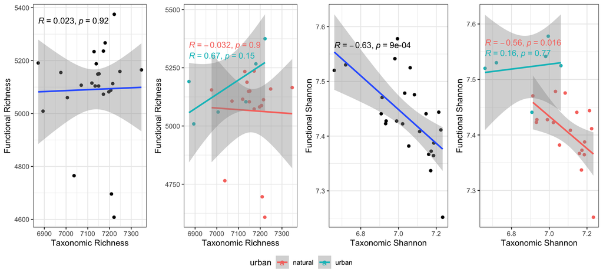

```r
c1 <- ggplot(md, aes(x = taxonomic_rich, y = functional_rich)) +
  geom_point() + geom_smooth(method = "lm") + stat_cor() +
  xlab("Taxonomic Richness") + ylab("Functional Richness") + theme_bw()

c2 <- ggplot(md, aes(x = taxonomic_rich, y = functional_rich, color = urban, group = urban)) +
  geom_point() + geom_smooth(method = "lm") + stat_cor() +
  xlab("Taxonomic Richness") + ylab("Functional Richness") + theme_bw()

c3 <- ggplot(md, aes(x = taxonomic_shannon, y = functional_shannon)) +
  geom_point() + geom_smooth(method = "lm") + stat_cor() +
  xlab("Taxonomic Shannon") + ylab("Functional Shannon") + theme_bw()

c4 <- ggplot(md, aes(x = taxonomic_shannon, y = functional_shannon, color = urban, group = urban)) +
  geom_point() + geom_smooth(method = "lm") + stat_cor() +
  xlab("Taxonomic Shannon") + ylab("Functional Shannon") + theme_bw()

ggarrange(c1, c2, c3, c4, ncol = 4, common.legend = TRUE, legend = "bottom")
```

> **Discussion question:** Do you see a stronger correlation for richness or Shannon diversity? Does the relationship differ between urban and natural samples?

## 7. Beta Diversity

### What is beta diversity?

**Beta diversity** describes the dissimilarity *between* samples — how different two communities are in composition. A high beta diversity means communities are very different from each other; low beta diversity means communities are similar.

### Bray-Curtis dissimilarity

We use the **Bray-Curtis dissimilarity** metric, which ranges from 0 (identical communities) to 1 (completely different):

$$BC_{ij} = 1 - \frac{2 \sum_k
\min(x_{ik}, x_{jk})}{\sum_k x_{ik} + \sum_k x_{jk}}$$

Bray-Curtis accounts for both the presence/absence of taxa *and* their relative abundances, making it more sensitive to ecological differences than presence-only metrics like Jaccard. We calculate it on RPM-normalized counts to remove sequencing depth effects.

### NMDS ordination

**Non-metric multidimensional scaling (NMDS)** is an ordination method that places samples in 2D space such that the rank order of distances between points reflects the rank order of their Bray-Curtis dissimilarities as faithfully as possible.

The key diagnostic is the **stress value**:

| Stress | Interpretation |
| --- | --- |
| < 0.05 | Excellent representation |
| < 0.10 | Good |
| < 0.20 | Acceptable |
| > 0.20 | Use with caution |

```r
taxonomy_counts_forbray <- rpm_taxonomy_counts %>%
  column_to_rownames(var = "sample")

# Calculate Bray-Curtis dissimilarity matrix
taxonomy.bray <- vegdist(taxonomy_counts_forbray, method = "bray")

# Run NMDS ordination
taxonomy.nmds <- metaMDS(taxonomy.bray)
```

```
## *** Best solution repeated 2 times
```

```r
# Extract ordination coordinates and add to metadata
md$taxonomy.Axis01 <- taxonomy.nmds$points[, 1]
md$taxonomy.Axis02 <- taxonomy.nmds$points[, 2]

cat("Taxonomic NMDS stress:", round(taxonomy.nmds$stress, 4), "\n")
```

```
## Taxonomic NMDS stress: 0.0797
```

```r
ko_counts_forbray <- rpm_ko_counts %>%
  column_to_rownames(var = "sample")

ko.bray  <- vegdist(ko_counts_forbray, method = "bray")
ko.nmds  <- metaMDS(ko.bray)
```

```
## *** Best solution was not repeated -- monoMDS stopping criteria:
##     20: stress ratio > sratmax
```

```r
md$ko.Axis01 <- ko.nmds$points[, 1]
md$ko.Axis02 <- ko.nmds$points[, 2]

cat("Functional NMDS stress:", round(ko.nmds$stress, 4), "\n")
```

```
## Functional NMDS stress: 0.0276
```

### Beta Diversity Plots

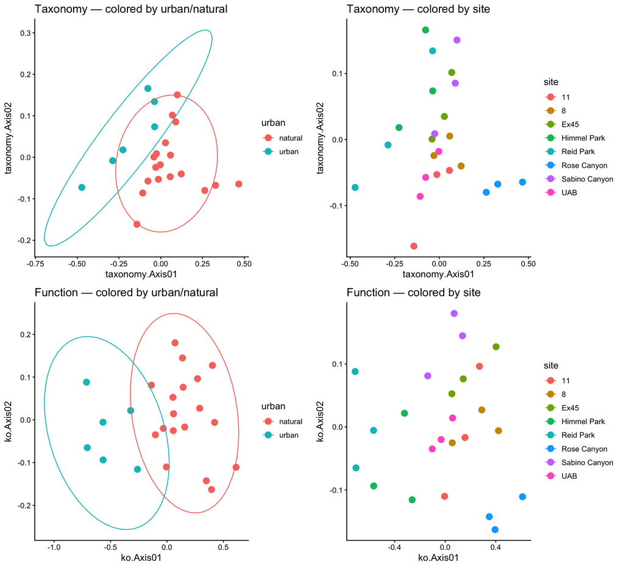

```r
b1 <- ggplot(md, aes(taxonomy.Axis01, taxonomy.Axis02)) +
  geom_point(aes(color = urban), size = 3.5) +
  stat_ellipse(aes(color = urban)) +
  theme_classic() +
  theme(legend.position = "right", text = element_text(size = 12)) +
  ggtitle("Taxonomy — colored by urban/natural")

b2 <- ggplot(md, aes(taxonomy.Axis01, taxonomy.Axis02)) +
  geom_point(aes(color = site), size = 3.5) +
  stat_ellipse(aes(color = site)) +
  theme_classic() +
  theme(legend.position = "right", text = element_text(size = 12)) +
  ggtitle("Taxonomy — colored by site")

b3 <- ggplot(md, aes(ko.Axis01, ko.Axis02)) +
  geom_point(aes(color = urban), size = 3.5) +
  stat_ellipse(aes(color = urban)) +
  theme_classic() +
  theme(legend.position = "right", text = element_text(size = 12)) +
  ggtitle("Function — colored by urban/natural")

b4 <- ggplot(md, aes(ko.Axis01, ko.Axis02)) +
  geom_point(aes(color = site), size = 3.5) +
  stat_ellipse(aes(color = site)) +
  theme_classic() +
  theme(legend.position = "right", text = element_text(size = 12)) +
  ggtitle("Function — colored by site")

ggarrange(b1, b2, b3, b4, ncol = 2, nrow = 2)
```

### Statistical Tests for Beta Diversity — PERMANOVA

**PERMANOVA** (Permutational Multivariate Analysis of Variance, implemented as `adonis2()` in `vegan`) tests whether groups of samples are more dissimilar to each other than expected by chance.

It works by: 1. Computing an observed pseudo-F statistic comparing within-group to between-group distances 2. Randomly permuting sample labels many times (here 999 permutations) 3. Asking: how often does a random permutation produce an F-statistic as large as the observed one?

The output gives: - **R²** — proportion of total variance in community composition explained by the grouping variable - **p-value** — probability of observing this R² by chance under the null hypothesis (all groups are the same)

```r
cat("--- PERMANOVA Results ---\n\n")
```

```
## --- PERMANOVA Results ---
```

```r
cat("Taxonomy ~ urban:\n")
```

```
## Taxonomy ~ urban:
```

```r
print(adonis2(taxonomy.bray ~ urban, data = md, permutations = 999, method = "bray"))
```

```
## Permutation test for adonis under reduced model
## Permutation: free
## Number of permutations: 999
##
## adonis2(formula = taxonomy.bray ~ urban, data = md, permutations = 999, method = "bray")
##          Df SumOfSqs      R2      F Pr(>F)
## Model     1  0.10842 0.20439 5.6516  0.002 **
## Residual 22  0.42204 0.79561
## Total    23  0.53046 1.00000
## ---
## Signif. codes:  0 '***' 0.001 '**' 0.01 '*' 0.05 '.' 0.1 ' ' 1
```

```r
cat("Taxonomy ~ site:\n")
```

```
## Taxonomy ~ site:
```

```r
print(adonis2(taxonomy.bray ~ site, data = md, permutations = 999, method = "bray"))
```

```
## Permutation test for adonis under reduced model
## Permutation: free
## Number of permutations: 999
##
## adonis2(formula = taxonomy.bray ~ site, data = md, permutations = 999, method = "bray")
##          Df SumOfSqs      R2      F Pr(>F)
## Model     7  0.33974 0.64046 4.0716  0.001 ***
## Residual 16  0.19072 0.35954
## Total    23  0.53046 1.00000
## ---
## Signif. codes:  0 '***' 0.001 '**' 0.01 '*' 0.05 '.' 0.1 ' ' 1
```

```r
cat("Function ~ urban:\n")
```

```
## Function ~ urban:
```

```r
print(adonis2(ko.bray ~ urban, data = md, permutations = 999, method = "bray"))
```

```
## Permutation test for adonis under reduced model
## Permutation: free
## Number of permutations: 999
##
## adonis2(formula = ko.bray ~ urban, data = md, permutations = 999, method = "bray")
##          Df SumOfSqs      R2      F Pr(>F)
## Model     1  0.60482 0.54316 26.157  0.001 ***
## Residual 22  0.50870 0.45684
## Total    23  1.11353 1.00000
## ---
## Signif. codes:  0 '***' 0.001 '**' 0.01 '*' 0.05 '.' 0.1 ' ' 1
```

```r
cat("Function ~ site:\n")
```

```
## Function ~ site:
```

```r
print(adonis2(ko.bray ~ site, data = md, permutations = 999, method = "bray"))
```

```
## Permutation test for adonis under reduced model
## Permutation: free
## Number of permutations: 999
##
## adonis2(formula = ko.bray ~ site, data = md, permutations = 999, method = "bray")
##          Df SumOfSqs      R2      F Pr(>F)
## Model     7  0.88943 0.79875 9.0717  0.001 ***
## Residual 16  0.22410 0.20125
## Total    23  1.11353 1.00000
## ---
## Signif. codes:  0 '***' 0.001 '**' 0.01 '*' 0.05 '.' 0.1 ' ' 1
```

> **Interpretation tip:** PERMANOVA is sensitive to both location (centroid) and dispersion (spread) differences between groups. If one group is more variable than another, PERMANOVA can return a significant result even if group centroids are similar. It is good practice to also test for homogeneity of dispersions using `betadisper()` if you get a significant result.

## 8. Summary

| Analysis | Method | What it tests |
| --- | --- | --- |
| Alpha diversity | `specnumber()` + `diversity()` on rarefied counts | Within-sample richness and evenness |
| Alpha statistics | `lm()` / `lmer()` + `Anova()` | Effect of urbanization on diversity, with/without site random effect |
| Beta diversity | Bray-Curtis + NMDS | Between-sample compositional dissimilarity, visualized |
| Beta statistics | PERMANOVA (`adonis2`) | Whether urban/natural groups differ in community composition |

*End of Day 3 Activity*